# ANCOVA in Vocabulary (Vocabulary)

Geiser C. Challco geiser@alumni.usp.br

- Setting Initial Variables
- Descriptive Statistics of Initial Data
- ANCOVA and Pairwise for one factor: **grupo**
  - Without remove non-normal data
  - Computing ANCOVA and PairWise After removing non-normal data (OK)
    - Plots for ancova
    - Checking linearity assumption
    - Checking normality and homogeneity
- ANCOVA and Pairwise for two factors **grupo:Sexo**
  - Without remove non-normal data
  - Computing ANCOVA and PairWise After removing non-normal data (OK)
    - Plots for ancova
    - Checking linearity assumption
    - Checking normality and homogeneity
- ANCOVA and Pairwise for two factors **grupo:Zona**
  - Without remove non-normal data
  - Computing ANCOVA and PairWise After removing non-normal data (OK)
    - Plots for ancova
    - Checking linearity assumption
    - Checking normality and homogeneity
- ANCOVA and Pairwise for two factors **grupo:Cor.Raca**
  - Without remove non-normal data
  - Computing ANCOVA and PairWise After removing non-normal data (OK)
    - Plots for ancova
    - Checking linearity assumption
    - Checking normality and homogeneity
- ANCOVA and Pairwise for two factors **grupo:Serie**
  - Without remove non-normal data
  - Computing ANCOVA and PairWise After removing non-normal data (OK)
    - Plots for ancova
    - Checking linearity assumption
    - Checking normality and homogeneity
- ANCOVA and Pairwise for two factors **grupo:vocab.quintile**
  - Without remove non-normal data
  - Computing ANCOVA and PairWise After removing non-normal data (OK)
    - Plots for ancova
    - Checking linearity assumption
    - Checking normality and homogeneity
- Summary of Results
  - Descriptive Statistics
  - ANCOVA Table Comparison
  - PairWise Table Comparison
  - EMMS Table Comparison

**NOTE**:

- Teste ANCOVA para determinar se houve diferenças significativas no Vocabulary (medido usando pre- e pos-testes).
- ANCOVA test to determine whether there were significant differences in Vocabulary (measured using pre- and post-tests).

# Setting Initial Variables

```r
dv = "vocab"
dv.pos = "vocab.pos"
dv.pre = "vocab.pre"

fatores2 <- c("Sexo","Zona","Cor.Raca","Serie","vocab.quintile")
lfatores2 <- as.list(fatores2)
names(lfatores2) <- fatores2

fatores1 <- c("grupo", fatores2)
lfatores1 <- as.list(fatores1)
names(lfatores1) <- fatores1

lfatores <- c(lfatores1)

color <- list()
color[["prepost"]] = c("#ffee65","#f28e2B")
color[["grupo"]] = c("#bcbd22","#fd7f6f")
color[["Sexo"]] = c("#FF007F","#4D4DFF")
color[["Zona"]] = c("#AA00FF","#00CCCC")
color[["Cor.Raca"]] = c(
  "Parda"="#b97100","Indígena"="#9F262F",
  "Branca"="#87c498", "Preta"="#848283","Amarela"="#D6B91C"
)

level <- list()
level[["grupo"]] = c("Controle","Experimental")
level[["Sexo"]] = c("F","M")
level[["Zona"]] = c("Rural","Urbana")
level[["Cor.Raca"]] = c("Parda","Indígena","Branca", "Preta","Amarela")
level[["Serie"]] = c("6 ano","7 ano","8 ano","9 ano")

# ..

ymin <- 0
ymax <- 0

ymin.ci <- 0
ymax.ci <- 0


color[["grupo:Sexo"]] = c(
  "Controle:F"="#ff99cb", "Controle:M"="#b7b7ff",
  "Experimental:F"="#FF007F", "Experimental:M"="#4D4DFF",
  "Controle.F"="#ff99cb", "Controle.M"="#b7b7ff",
  "Experimental.F"="#FF007F", "Experimental.M"="#4D4DFF"
)
color[["grupo:Zona"]] = c(
  "Controle:Rural"="#b2efef","Controle:Urbana"="#e5b2ff",
  "Experimental:Rural"="#00CCCC", "Experimental:Urbana"="#AA00FF",
  "Controle.Rural"="#b2efef","Controle.Urbana"="#e5b2ff",
  "Experimental.Rural"="#00CCCC", "Experimental.Urbana"="#AA00FF"
)
color[["grupo:Cor.Raca"]] = c(
    "Controle:Parda"="#e3c699", "Experimental:Parda"="#b97100",
    "Controle:Indígena"="#e2bdc0", "Experimental:Indígena"="#9F262F",
    "Controle:Branca"="#c0e8cb", "Experimental:Branca"="#87c498",
    "Controle:Preta"="#dad9d9", "Experimental:Preta"="#848283",
    "Controle:Amarela"="#eee3a4", "Experimental:Amarela"="#D6B91C",

    "Controle.Parda"="#e3c699", "Experimental.Parda"="#b97100",
    "Controle.Indígena"="#e2bdc0", "Experimental.Indígena"="#9F262F",
    "Controle.Branca"="#c0e8cb", "Experimental.Branca"="#87c498",
    "Controle.Preta"="#dad9d9", "Experimental.Preta"="#848283",
    "Controle.Amarela"="#eee3a4", "Experimental.Amarela"="#D6B91C"
)


for (coln in c("vocab","vocab.teach","vocab.non.teach","score.tde",
               "TFL.lidas.per.min","TFL.corretas.per.min","TFL.erradas.per.min","TFL.omitidas.per.min",
               "leitura.compreensao")) {
  color[[paste0(coln,".quintile")]] = c("#BF0040","#FF0000","#800080","#0000FF","#4000BF")
  level[[paste0(coln,".quintile")]] = c("1st quintile","2nd quintile","3rd quintile","4th quintile","5th quintile")
  color[[paste0("grupo:",coln,".quintile")]] = c(
    "Experimental.1st quintile"="#BF0040", "Controle.1st quintile"="#d8668c",
    "Experimental.2nd quintile"="#FF0000", "Controle.2nd quintile"="#ff7f7f",
    "Experimental.3rd quintile"="#8fce00", "Controle.3rd quintile"="#ddf0b2",
    "Experimental.4th quintile"="#0000FF", "Controle.4th quintile"="#b2b2ff",
    "Experimental.5th quintile"="#4000BF", "Controle.5th quintile"="#b299e5",

    "Experimental:1st quintile"="#BF0040", "Controle:1st quintile"="#d8668c",
    "Experimental:2nd quintile"="#FF0000", "Controle:2nd quintile"="#ff7f7f",
    "Experimental:3rd quintile"="#8fce00", "Controle:3rd quintile"="#ddf0b2",
    "Experimental:4th quintile"="#0000FF", "Controle:4th quintile"="#b2b2ff",
    "Experimental:5th quintile"="#4000BF", "Controle:5th quintile"="#b299e5")
}


gdat <- read_excel("../data/data.xlsx", sheet = "sumary")
gdat <- gdat[which(is.na(gdat$Necessidade.Deficiencia) & !is.na(gdat$Stari.Grupo)),]



dat <- gdat
dat$grupo <- factor(dat[["Stari.Grupo"]], level[["grupo"]])
for (coln in c(names(lfatores))) {
  dat[[coln]] <- factor(dat[[coln]], level[[coln]][level[[coln]] %in% unique(dat[[coln]])])
}
dat <- dat[which(!is.na(dat[[dv.pre]]) & !is.na(dat[[dv.pos]])),]
dat <- dat[,c("id",names(lfatores),dv.pre,dv.pos)]

dat.long <- rbind(dat, dat)
dat.long$time <- c(rep("pre", nrow(dat)), rep("pos", nrow(dat)))
dat.long$time <- factor(dat.long$time, c("pre","pos"))
dat.long[[dv]] <- c(dat[[dv.pre]], dat[[dv.pos]])


for (f in c("grupo", names(lfatores))) {
  if (is.null(color[[f]]) && length(unique(dat[[f]])) > 0)
      color[[f]] <- distinctColorPalette(length(unique(dat[[f]])))
}
for (f in c(fatores2)) {
  if (is.null(color[[paste0("grupo:",f)]]) && length(unique(dat[[f]])) > 0)
    color[[paste0("grupo:",f)]] <- distinctColorPalette(length(unique(dat[["grupo"]]))*length(unique(dat[[f]])))
}

ldat <- list()
laov <- list()
lpwc <- list()
lemms <- list()
```

# Descriptive Statistics of Initial Data

```r
df <- get.descriptives(dat, c(dv.pre, dv.pos), c("grupo"),
                       include.global = T, symmetry.test = T, normality.test = F)
df <- plyr::rbind.fill(
  df, do.call(plyr::rbind.fill, lapply(lfatores2, FUN = function(f) {
    if (nrow(dat) > 0 && sum(!is.na(unique(dat[[f]]))) > 1)
      get.descriptives(dat, c(dv.pre,dv.pos), c("grupo", f),
                       symmetry.test = T, normality.test = F)
    }))
)
df <- df[,c(fatores1[fatores1 %in% colnames(df)],"variable",
            colnames(df)[!colnames(df) %in% c(fatores1,"variable")])]
```

| grupo | Sexo | Zona | Cor.Raca | Serie | vocab.quintile | variable | n | mean | median | min | max | sd | se | ci | iqr | symmetry | skewness | kurtosis |
| --- | --- | --- | --- | --- | --- | --- | --- | --- | --- | --- | --- | --- | --- | --- | --- | --- | --- | --- |
| Controle |  |  |  |  |  | vocab.pre | 98 | 23.980 | 23.0 | 7 | 45 | 7.824 | 0.790 | 1.569 | 10.00 | YES | 0.389 | -0.356 |
| Experimental |  |  |  |  |  | vocab.pre | 48 | 23.208 | 24.0 | 7 | 39 | 7.092 | 1.024 | 2.059 | 9.50 | YES | -0.315 | -0.462 |
|  |  |  |  |  |  | vocab.pre | 146 | 23.726 | 24.0 | 7 | 45 | 7.575 | 0.627 | 1.239 | 10.00 | YES | 0.216 | -0.265 |
| Controle |  |  |  |  |  | vocab.pos | 98 | 24.633 | 23.0 | 11 | 47 | 8.458 | 0.854 | 1.696 | 11.50 | NO | 0.597 | -0.409 |
| Experimental |  |  |  |  |  | vocab.pos | 48 | 24.333 | 24.5 | 8 | 40 | 7.603 | 1.097 | 2.208 | 10.25 | YES | -0.015 | -0.642 |
|  |  |  |  |  |  | vocab.pos | 146 | 24.534 | 23.0 | 8 | 47 | 8.161 | 0.675 | 1.335 | 10.75 | YES | 0.447 | -0.386 |
| Controle | F |  |  |  |  | vocab.pre | 43 | 24.535 | 25.0 | 12 | 36 | 6.874 | 1.048 | 2.116 | 9.00 | YES | -0.003 | -1.003 |
| Controle | M |  |  |  |  | vocab.pre | 55 | 23.545 | 22.0 | 7 | 45 | 8.531 | 1.150 | 2.306 | 12.00 | NO | 0.588 | -0.233 |
| Experimental | F |  |  |  |  | vocab.pre | 16 | 24.000 | 25.5 | 11 | 33 | 6.976 | 1.744 | 3.717 | 7.75 | NO | -0.631 | -0.789 |
| Experimental | M |  |  |  |  | vocab.pre | 32 | 22.812 | 23.5 | 7 | 39 | 7.226 | 1.277 | 2.605 | 10.25 | YES | -0.148 | -0.386 |
| Controle | F |  |  |  |  | vocab.pos | 43 | 24.907 | 23.0 | 14 | 40 | 6.938 | 1.058 | 2.135 | 7.50 | NO | 0.698 | -0.419 |
| Controle | M |  |  |  |  | vocab.pos | 55 | 24.418 | 23.0 | 11 | 47 | 9.537 | 1.286 | 2.578 | 13.50 | NO | 0.563 | -0.687 |
| Experimental | F |  |  |  |  | vocab.pos | 16 | 24.062 | 23.0 | 17 | 40 | 5.767 | 1.442 | 3.073 | 9.00 | NO | 1.055 | 1.067 |
| Experimental | M |  |  |  |  | vocab.pos | 32 | 24.469 | 25.5 | 8 | 39 | 8.455 | 1.495 | 3.048 | 13.00 | YES | -0.210 | -1.095 |
| Controle |  | Rural |  |  |  | vocab.pre | 56 | 23.607 | 23.0 | 12 | 44 | 7.065 | 0.944 | 1.892 | 9.50 | YES | 0.382 | -0.340 |
| Controle |  | Urbana |  |  |  | vocab.pre | 11 | 22.455 | 20.0 | 7 | 45 | 10.539 | 3.178 | 7.080 | 9.50 | NO | 0.669 | -0.409 |
| Controle |  |  |  |  |  | vocab.pre | 31 | 25.194 | 24.0 | 12 | 42 | 8.171 | 1.468 | 2.997 | 12.50 | YES | 0.173 | -1.104 |
| Experimental |  | Rural |  |  |  | vocab.pre | 34 | 22.618 | 24.0 | 7 | 39 | 7.274 | 1.247 | 2.538 | 8.50 | YES | -0.208 | -0.361 |
| Experimental |  | Urbana |  |  |  | vocab.pre | 5 | 26.200 | 26.0 | 15 | 33 | 7.463 | 3.338 | 9.267 | 9.00 | YES | -0.379 | -1.708 |
| Experimental |  |  |  |  |  | vocab.pre | 9 | 23.778 | 24.0 | 13 | 30 | 6.476 | 2.159 | 4.978 | 6.00 | NO | -0.609 | -1.314 |
| Controle |  | Rural |  |  |  | vocab.pos | 56 | 24.821 | 23.0 | 11 | 47 | 8.651 | 1.156 | 2.317 | 11.25 | YES | 0.483 | -0.337 |
| Controle |  | Urbana |  |  |  | vocab.pos | 11 | 22.091 | 20.0 | 12 | 41 | 8.166 | 2.462 | 5.486 | 7.50 | NO | 0.985 | 0.027 |
| Controle |  |  |  |  |  | vocab.pos | 31 | 25.194 | 23.0 | 14 | 41 | 8.312 | 1.493 | 3.049 | 10.50 | NO | 0.641 | -0.930 |
| Experimental |  | Rural |  |  |  | vocab.pos | 34 | 24.059 | 24.0 | 8 | 39 | 7.847 | 1.346 | 2.738 | 10.75 | YES | -0.142 | -0.792 |
| Experimental |  | Urbana |  |  |  | vocab.pos | 5 | 23.400 | 23.0 | 16 | 34 | 7.127 | 3.187 | 8.850 | 8.00 | YES | 0.357 | -1.720 |
| Experimental |  |  |  |  |  | vocab.pos | 9 | 25.889 | 26.0 | 15 | 40 | 7.524 | 2.508 | 5.783 | 8.00 | YES | 0.380 | -0.948 |
| Controle |  |  | Parda |  |  | vocab.pre | 45 | 23.156 | 23.0 | 12 | 44 | 7.517 | 1.120 | 2.258 | 10.00 | YES | 0.488 | -0.335 |
| Controle |  |  | Indígena |  |  | vocab.pre | 3 | 27.000 | 26.0 | 24 | 31 | 3.606 | 2.082 | 8.957 | 3.50 | few data | 0.000 | 0.000 |
| Controle |  |  | Branca |  |  | vocab.pre | 11 | 23.909 | 27.0 | 14 | 31 | 6.363 | 1.919 | 4.275 | 11.00 | YES | -0.423 | -1.709 |
| Controle |  |  | Preta |  |  | vocab.pre | 1 | 19.000 | 19.0 | 19 | 19 |  |  |  | 0.00 | few data | 0.000 | 0.000 |
| Controle |  |  |  |  |  | vocab.pre | 38 | 24.868 | 23.0 | 7 | 45 | 8.866 | 1.438 | 2.914 | 14.00 | YES | 0.315 | -0.707 |
| Experimental |  |  | Parda |  |  | vocab.pre | 18 | 21.389 | 22.0 | 7 | 39 | 8.925 | 2.104 | 4.439 | 12.75 | YES | 0.068 | -1.053 |
| Experimental |  |  | Indígena |  |  | vocab.pre | 6 | 24.833 | 23.5 | 18 | 33 | 5.345 | 2.182 | 5.609 | 5.50 | YES | 0.293 | -1.569 |
| Experimental |  |  | Branca |  |  | vocab.pre | 5 | 21.200 | 23.0 | 15 | 28 | 5.541 | 2.478 | 6.880 | 8.00 | YES | -0.043 | -2.062 |
| Experimental |  |  |  |  |  | vocab.pre | 19 | 24.947 | 25.0 | 13 | 33 | 5.730 | 1.315 | 2.762 | 6.00 | NO | -0.594 | -0.555 |
| Controle |  |  | Parda |  |  | vocab.pos | 45 | 23.622 | 23.0 | 11 | 45 | 7.904 | 1.178 | 2.375 | 7.00 | NO | 0.612 | -0.003 |
| Controle |  |  | Indígena |  |  | vocab.pos | 3 | 28.000 | 27.0 | 25 | 32 | 3.606 | 2.082 | 8.957 | 3.50 | few data | 0.000 | 0.000 |
| Controle |  |  | Branca |  |  | vocab.pos | 11 | 25.727 | 27.0 | 14 | 40 | 8.296 | 2.501 | 5.573 | 13.00 | YES | 0.140 | -1.465 |
| Controle |  |  | Preta |  |  | vocab.pos | 1 | 23.000 | 23.0 | 23 | 23 |  |  |  | 0.00 | few data | 0.000 | 0.000 |
| Controle |  |  |  |  |  | vocab.pos | 38 | 25.289 | 23.0 | 12 | 47 | 9.535 | 1.547 | 3.134 | 12.75 | NO | 0.607 | -0.904 |
| Experimental |  |  | Parda |  |  | vocab.pos | 18 | 22.111 | 21.0 | 8 | 39 | 8.217 | 1.937 | 4.086 | 11.50 | YES | 0.331 | -0.790 |
| Experimental |  |  | Indígena |  |  | vocab.pos | 6 | 21.667 | 24.0 | 10 | 28 | 6.653 | 2.716 | 6.982 | 6.50 | NO | -0.714 | -1.231 |
| Experimental |  |  | Branca |  |  | vocab.pos | 5 | 28.000 | 31.0 | 16 | 35 | 7.450 | 3.332 | 9.250 | 6.00 | NO | -0.630 | -1.475 |
| Experimental |  |  |  |  |  | vocab.pos | 19 | 26.316 | 26.0 | 14 | 40 | 6.880 | 1.578 | 3.316 | 7.50 | YES | 0.123 | -0.695 |
| Controle |  |  |  | 6 ano |  | vocab.pre | 26 | 19.423 | 18.5 | 12 | 29 | 5.551 | 1.089 | 2.242 | 8.50 | YES | 0.275 | -1.373 |
| Controle |  |  |  | 7 ano |  | vocab.pre | 28 | 23.286 | 23.0 | 12 | 35 | 5.974 | 1.129 | 2.317 | 9.00 | YES | 0.142 | -0.813 |
| Controle |  |  |  | 8 ano |  | vocab.pre | 17 | 23.882 | 19.0 | 7 | 45 | 10.688 | 2.592 | 5.495 | 16.00 | NO | 0.658 | -0.739 |
| Controle |  |  |  | 9 ano |  | vocab.pre | 27 | 29.148 | 29.0 | 13 | 42 | 6.509 | 1.253 | 2.575 | 9.50 | YES | -0.370 | -0.275 |
| Experimental |  |  |  | 6 ano |  | vocab.pre | 13 | 22.385 | 24.0 | 9 | 30 | 7.066 | 1.960 | 4.270 | 10.00 | NO | -0.583 | -1.102 |
| Experimental |  |  |  | 7 ano |  | vocab.pre | 13 | 23.692 | 23.0 | 13 | 39 | 7.674 | 2.129 | 4.638 | 8.00 | YES | 0.455 | -0.930 |
| Experimental |  |  |  | 8 ano |  | vocab.pre | 14 | 22.357 | 23.5 | 7 | 33 | 8.409 | 2.247 | 4.855 | 14.25 | YES | -0.363 | -1.307 |
| Experimental |  |  |  | 9 ano |  | vocab.pre | 8 | 25.250 | 25.0 | 19 | 29 | 3.454 | 1.221 | 2.887 | 4.50 | YES | -0.403 | -1.235 |
| Controle |  |  |  | 6 ano |  | vocab.pos | 26 | 18.692 | 18.5 | 11 | 27 | 4.994 | 0.979 | 2.017 | 8.25 | YES | 0.037 | -1.282 |
| Controle |  |  |  | 7 ano |  | vocab.pos | 28 | 26.464 | 24.0 | 12 | 47 | 8.194 | 1.549 | 3.177 | 8.50 | NO | 0.644 | -0.211 |
| Controle |  |  |  | 8 ano |  | vocab.pos | 17 | 24.000 | 21.0 | 14 | 45 | 9.605 | 2.329 | 4.938 | 11.00 | NO | 0.940 | -0.562 |
| Controle |  |  |  | 9 ano |  | vocab.pos | 27 | 28.852 | 29.0 | 14 | 41 | 7.665 | 1.475 | 3.032 | 10.00 | YES | -0.076 | -1.152 |
| Experimental |  |  |  | 6 ano |  | vocab.pos | 13 | 23.538 | 25.0 | 14 | 35 | 6.280 | 1.742 | 3.795 | 9.00 | YES | -0.102 | -1.103 |
| Experimental |  |  |  | 7 ano |  | vocab.pos | 13 | 23.077 | 22.0 | 10 | 39 | 8.401 | 2.330 | 5.077 | 10.00 | YES | 0.127 | -1.001 |
| Experimental |  |  |  | 8 ano |  | vocab.pos | 14 | 24.857 | 25.0 | 8 | 37 | 8.690 | 2.323 | 5.017 | 13.25 | YES | -0.248 | -1.225 |
| Experimental |  |  |  | 9 ano |  | vocab.pos | 8 | 26.750 | 25.5 | 18 | 40 | 6.923 | 2.448 | 5.788 | 7.25 | NO | 0.589 | -0.890 |
| Controle |  |  |  |  | 1st quintile | vocab.pre | 17 | 13.529 | 14.0 | 7 | 16 | 2.267 | 0.550 | 1.166 | 3.00 | NO | -1.142 | 1.450 |
| Controle |  |  |  |  | 2nd quintile | vocab.pre | 28 | 19.286 | 19.0 | 17 | 22 | 1.462 | 0.276 | 0.567 | 1.00 | YES | 0.273 | -0.622 |
| Controle |  |  |  |  | 3rd quintile | vocab.pre | 31 | 26.097 | 27.0 | 23 | 29 | 2.166 | 0.389 | 0.794 | 4.00 | YES | -0.216 | -1.517 |
| Controle |  |  |  |  | 4th quintile | vocab.pre | 9 | 31.667 | 31.0 | 30 | 34 | 1.414 | 0.471 | 1.087 | 2.00 | YES | 0.288 | -1.556 |
| Controle |  |  |  |  | 5th quintile | vocab.pre | 13 | 37.385 | 36.0 | 35 | 45 | 3.664 | 1.016 | 2.214 | 1.00 | NO | 1.171 | -0.476 |
| Experimental |  |  |  |  | 1st quintile | vocab.pre | 9 | 12.111 | 13.0 | 7 | 16 | 2.892 | 0.964 | 2.223 | 3.00 | YES | -0.346 | -1.265 |
| Experimental |  |  |  |  | 2nd quintile | vocab.pre | 8 | 19.125 | 19.0 | 17 | 22 | 1.808 | 0.639 | 1.511 | 2.50 | YES | 0.220 | -1.553 |
| Experimental |  |  |  |  | 3rd quintile | vocab.pre | 21 | 25.286 | 25.0 | 23 | 29 | 1.978 | 0.432 | 0.901 | 2.00 | NO | 0.544 | -1.059 |
| Experimental |  |  |  |  | 4th quintile | vocab.pre | 9 | 31.333 | 30.0 | 30 | 33 | 1.581 | 0.527 | 1.215 | 3.00 | few data | 0.000 | 0.000 |
| Experimental |  |  |  |  | 5th quintile | vocab.pre | 1 | 39.000 | 39.0 | 39 | 39 |  |  |  | 0.00 | few data | 0.000 | 0.000 |
| Controle |  |  |  |  | 1st quintile | vocab.pos | 17 | 17.294 | 18.0 | 11 | 23 | 3.771 | 0.915 | 1.939 | 5.00 | YES | -0.367 | -1.195 |
| Controle |  |  |  |  | 2nd quintile | vocab.pos | 28 | 21.393 | 21.5 | 12 | 47 | 7.233 | 1.367 | 2.805 | 6.75 | NO | 1.512 | 3.304 |
| Controle |  |  |  |  | 3rd quintile | vocab.pos | 31 | 25.613 | 25.0 | 14 | 40 | 6.009 | 1.079 | 2.204 | 4.50 | YES | 0.435 | 0.073 |
| Controle |  |  |  |  | 4th quintile | vocab.pos | 9 | 32.556 | 32.0 | 16 | 40 | 7.248 | 2.416 | 5.571 | 7.00 | NO | -1.053 | 0.290 |
| Controle |  |  |  |  | 5th quintile | vocab.pos | 13 | 33.385 | 38.0 | 17 | 45 | 9.106 | 2.526 | 5.503 | 13.00 | NO | -0.582 | -1.250 |
| Experimental |  |  |  |  | 1st quintile | vocab.pos | 9 | 17.333 | 16.0 | 8 | 31 | 6.837 | 2.279 | 5.256 | 4.00 | NO | 0.611 | -0.655 |
| Experimental |  |  |  |  | 2nd quintile | vocab.pos | 8 | 19.000 | 19.5 | 10 | 30 | 6.188 | 2.188 | 5.173 | 6.75 | YES | 0.260 | -1.092 |
| Experimental |  |  |  |  | 3rd quintile | vocab.pos | 21 | 27.238 | 26.0 | 18 | 40 | 6.057 | 1.322 | 2.757 | 9.00 | YES | 0.433 | -0.869 |
| Experimental |  |  |  |  | 4th quintile | vocab.pos | 9 | 27.667 | 28.0 | 19 | 34 | 4.743 | 1.581 | 3.646 | 5.00 | YES | -0.365 | -1.109 |
| Experimental |  |  |  |  | 5th quintile | vocab.pos | 1 | 39.000 | 39.0 | 39 | 39 |  |  |  | 0.00 | few data | 0.000 | 0.000 |

# ANCOVA and Pairwise for one factor: **grupo**

## Without remove non-normal data

```r
pdat = remove_group_data(dat[!is.na(dat[["grupo"]]),], "vocab.pos", "grupo")

pdat.long <- rbind(pdat[,c("id","grupo")], pdat[,c("id","grupo")])
pdat.long[["time"]] <- c(rep("pre", nrow(pdat)), rep("pos", nrow(pdat)))
pdat.long[["time"]] <- factor(pdat.long[["time"]], c("pre","pos"))
pdat.long[["vocab"]] <- c(pdat[["vocab.pre"]], pdat[["vocab.pos"]])

aov = anova_test(pdat, vocab.pos ~ vocab.pre + grupo)
laov[["grupo"]] <- get_anova_table(aov)
```

```r
pwc <- emmeans_test(pdat, vocab.pos ~ grupo, covariate = vocab.pre,
                    p.adjust.method = "bonferroni")
```

```r
pwc.long <- emmeans_test(dplyr::group_by_at(pdat.long, "grupo"),
                          vocab ~ time,
                          p.adjust.method = "bonferroni")
lpwc[["grupo"]] <- plyr::rbind.fill(pwc, pwc.long)
```

```r
ds <- get.descriptives(pdat, "vocab.pos", "grupo", covar = "vocab.pre")
ds <- merge(ds[ds$variable != "vocab.pre",],
            ds[ds$variable == "vocab.pre", !colnames(ds) %in% c("variable")],
            by = "grupo", all.x = T, suffixes = c("", ".vocab.pre"))
ds <- merge(get_emmeans(pwc), ds, by = "grupo", suffixes = c(".emms", ""))
ds <- ds[,c("grupo","n","mean.vocab.pre","se.vocab.pre","mean","se",
            "emmean","se.emms","conf.low","conf.high")]

colnames(ds) <- c("grupo", "N", paste0(c("M","SE")," (pre)"),
                  paste0(c("M","SE"), " (unadj)"),
                  paste0(c("M", "SE"), " (adj)"), "conf.low", "conf.high")

lemms[["grupo"]] <- ds
```

## Computing ANCOVA and PairWise After removing non-normal data (OK)

```r
wdat = pdat

res = residuals(lm(vocab.pos ~ vocab.pre + grupo, data = wdat))
non.normal = getNonNormal(res, wdat$id, plimit = 0.05)

wdat = wdat[!wdat$id %in% non.normal,]

wdat.long <- rbind(wdat[,c("id","grupo")], wdat[,c("id","grupo")])
wdat.long[["time"]] <- c(rep("pre", nrow(wdat)), rep("pos", nrow(wdat)))
wdat.long[["time"]] <- factor(wdat.long[["time"]], c("pre","pos"))
wdat.long[["vocab"]] <- c(wdat[["vocab.pre"]], wdat[["vocab.pos"]])

ldat[["grupo"]] = wdat

(non.normal)
```

```
## [1] "P3569"
```

```r
aov = anova_test(wdat, vocab.pos ~ vocab.pre + grupo)
laov[["grupo"]] <- merge(get_anova_table(aov), laov[["grupo"]],
                            by="Effect", suffixes = c("","'"))

(df = get_anova_table(aov))
```

```
## ANOVA Table (type II tests)
##
##      Effect DFn DFd       F        p p<.05   ges
## 1 vocab.pre   1 142 126.192 2.39e-21     * 0.471
## 2     grupo   1 142   0.258 6.12e-01       0.002
```

| Effect | DFn | DFd | F | p | p<.05 | ges |
| --- | --- | --- | --- | --- | --- | --- |
| vocab.pre | 1 | 142 | 126.192 | 0.000 | * | 0.471 |
| grupo | 1 | 142 | 0.258 | 0.612 |  | 0.002 |

```r
pwc <- emmeans_test(wdat, vocab.pos ~ grupo, covariate = vocab.pre,
                    p.adjust.method = "bonferroni")
```

| term | .y. | group1 | group2 | df | statistic | p | p.adj | p.adj.signif |
| --- | --- | --- | --- | --- | --- | --- | --- | --- |
| vocab.pre*grupo | vocab.pos | Controle | Experimental | 142 | -0.508 | 0.612 | 0.612 | ns |

```r
pwc.long <- emmeans_test(dplyr::group_by_at(wdat.long, "grupo"),
                         vocab ~ time,
                         p.adjust.method = "bonferroni")
lpwc[["grupo"]] <- merge(plyr::rbind.fill(pwc, pwc.long), lpwc[["grupo"]],
                            by=c("grupo","term",".y.","group1","group2"),
                            suffixes = c("","'"))
```

| grupo | term | .y. | group1 | group2 | df | statistic | p | p.adj | p.adj.signif |
| --- | --- | --- | --- | --- | --- | --- | --- | --- | --- |
| Controle | time | vocab | pre | pos | 286 | -0.331 | 0.741 | 0.741 | ns |
| Experimental | time | vocab | pre | pos | 286 | -0.706 | 0.481 | 0.481 | ns |

```r
ds <- get.descriptives(wdat, "vocab.pos", "grupo", covar = "vocab.pre")
ds <- merge(ds[ds$variable != "vocab.pre",],
            ds[ds$variable == "vocab.pre", !colnames(ds) %in% c("variable")],
            by = "grupo", all.x = T, suffixes = c("", ".vocab.pre"))
ds <- merge(get_emmeans(pwc), ds, by = "grupo", suffixes = c(".emms", ""))
ds <- ds[,c("grupo","n","mean.vocab.pre","se.vocab.pre","mean","se",
            "emmean","se.emms","conf.low","conf.high")]

colnames(ds) <- c("grupo", "N", paste0(c("M","SE")," (pre)"),
                  paste0(c("M","SE"), " (unadj)"),
                  paste0(c("M", "SE"), " (adj)"), "conf.low", "conf.high")

lemms[["grupo"]] <- merge(ds, lemms[["grupo"]], by=c("grupo"), suffixes = c("","'"))
```

| grupo | N | M (pre) | SE (pre) | M (unadj) | SE (unadj) | M (adj) | SE (adj) | conf.low | conf.high |
| --- | --- | --- | --- | --- | --- | --- | --- | --- | --- |
| Controle | 97 | 24.031 | 0.797 | 24.402 | 0.831 | 24.206 | 0.593 | 23.033 | 25.379 |
| Experimental | 48 | 23.208 | 1.024 | 24.333 | 1.097 | 24.730 | 0.844 | 23.062 | 26.398 |

### Plots for ancova

```r
plots <- oneWayAncovaPlots(
  wdat, "vocab.pos", "grupo", aov, list("grupo"=pwc), addParam = c("mean_ci"),
  font.label.size=10, step.increase=0.05, p.label="p.adj",
  subtitle = which(aov$Effect == "grupo"))
```

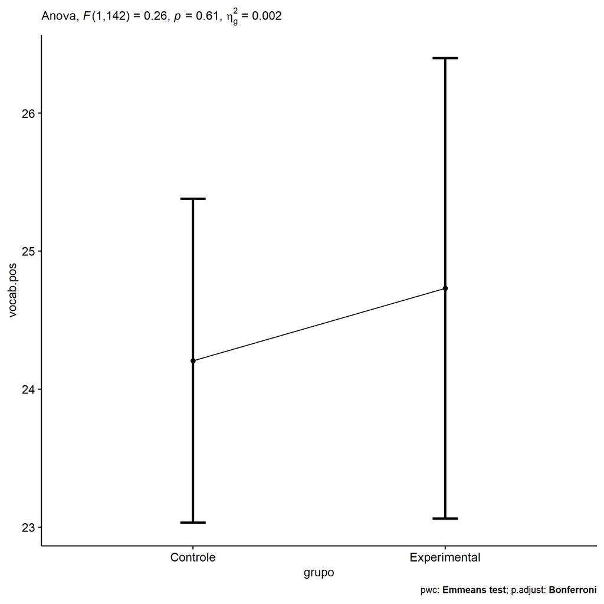

```r
if (!is.null(nrow(plots[["grupo"]]$data)))
  plots[["grupo"]] +
  if (ymin.ci < ymax.ci) ggplot2::ylim(ymin.ci, ymax.ci)
```

```r
plots <- oneWayAncovaBoxPlots(
  wdat, "vocab.pos", "grupo", aov, pwc, covar = "vocab.pre",
  theme = "classic", color = color[["grupo"]],
  subtitle = which(aov$Effect == "grupo"))
```

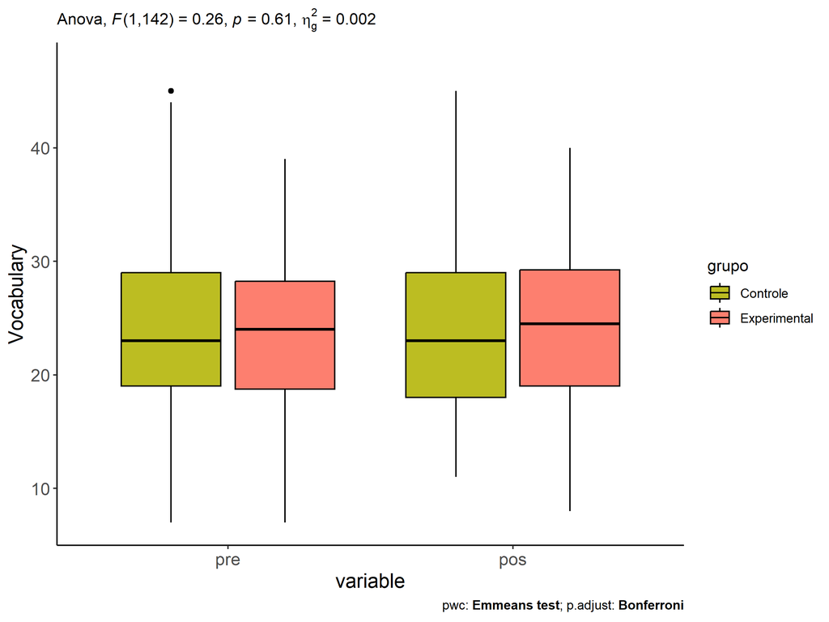

```r
if (length(unique(wdat[["grupo"]])) > 1)
  plots[["grupo"]] + ggplot2::ylab("Vocabulary") +
  ggplot2::scale_x_discrete(labels=c('pre', 'pos')) +
  if (ymin < ymax) ggplot2::ylim(ymin, ymax)
```

```r
if (length(unique(wdat.long[["grupo"]])) > 1)
  plots <- oneWayAncovaBoxPlots(
    wdat.long, "vocab", "grupo", aov, pwc.long,
    pre.post = "time", theme = "classic", color = color$prepost)
```

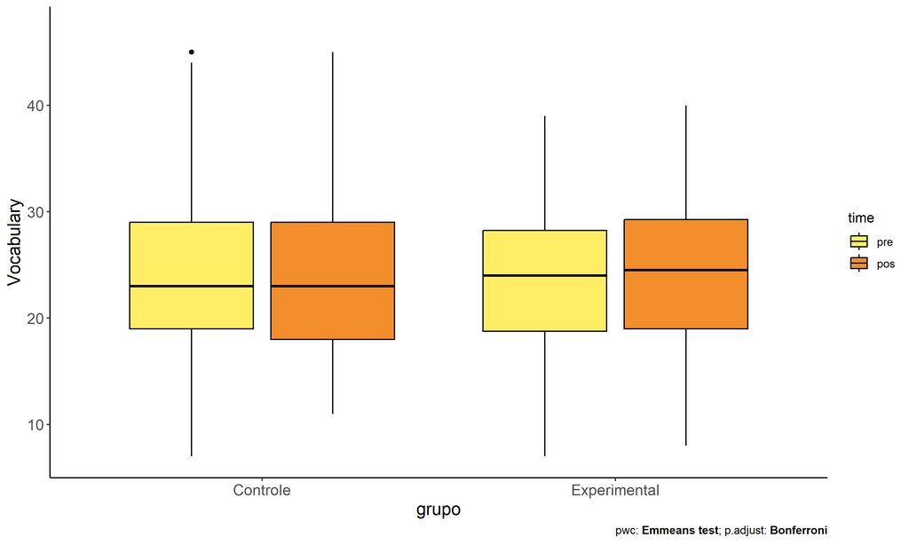

```r
if (length(unique(wdat.long[["grupo"]])) > 1)
  plots[["grupo"]] + ggplot2::ylab("Vocabulary") +
  if (ymin < ymax) ggplot2::ylim(ymin, ymax)
```

### Checking linearity assumption

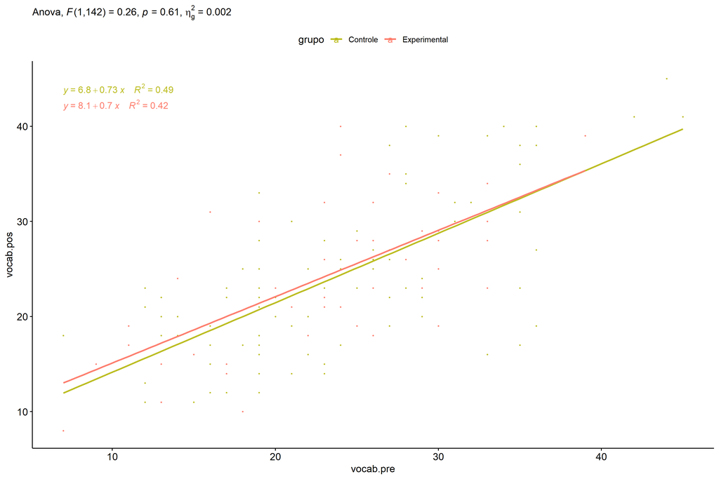

```r
ggscatter(wdat, x = "vocab.pre", y = "vocab.pos", size = 0.5,
          color = "grupo", add = "reg.line")+
  stat_regline_equation(
    aes(label =  paste(..eq.label.., ..rr.label.., sep = "~~~~"), color = grupo)
  ) +
  ggplot2::labs(subtitle = rstatix::get_test_label(aov, detailed = T, row = which(aov$Effect == "grupo"))) +
  ggplot2::scale_color_manual(values = color[["grupo"]]) +
  if (ymin < ymax) ggplot2::ylim(ymin, ymax)
```

### Checking normality and homogeneity

```r
res <- augment(lm(vocab.pos ~ vocab.pre + grupo, data = wdat))
```

```r
shapiro_test(res$.resid)
```

```
## # A tibble: 1 × 3
##   variable   statistic p.value
##   <chr>          <dbl>   <dbl>
## 1 res$.resid     0.995   0.914
```

```r
levene_test(res, .resid ~ grupo)
```

```
## # A tibble: 1 × 4
##     df1   df2 statistic     p
##   <int> <int>     <dbl> <dbl>
## 1     1   143    0.0402 0.841
```

# ANCOVA and Pairwise for two factors **grupo:Sexo**

## Without remove non-normal data

```r
pdat = remove_group_data(dat[!is.na(dat[["grupo"]]) & !is.na(dat[["Sexo"]]),],
                         "vocab.pos", c("grupo","Sexo"))
pdat = pdat[pdat[["Sexo"]] %in% do.call(
  intersect, lapply(unique(pdat[["grupo"]]), FUN = function(x) {
    unique(pdat[["Sexo"]][which(pdat[["grupo"]] == x)])
  })),]
pdat[["grupo"]] = factor(pdat[["grupo"]], level[["grupo"]])
pdat[["Sexo"]] = factor(
  pdat[["Sexo"]],
  level[["Sexo"]][level[["Sexo"]] %in% unique(pdat[["Sexo"]])])

pdat.long <- rbind(pdat[,c("id","grupo","Sexo")], pdat[,c("id","grupo","Sexo")])
pdat.long[["time"]] <- c(rep("pre", nrow(pdat)), rep("pos", nrow(pdat)))
pdat.long[["time"]] <- factor(pdat.long[["time"]], c("pre","pos"))
pdat.long[["vocab"]] <- c(pdat[["vocab.pre"]], pdat[["vocab.pos"]])

if (length(unique(pdat[["Sexo"]])) >= 2) {
  aov = anova_test(pdat, vocab.pos ~ vocab.pre + grupo*Sexo)
  laov[["grupo:Sexo"]] <- get_anova_table(aov)
}
```

```r
if (length(unique(pdat[["Sexo"]])) >= 2) {
  pwcs <- list()
  pwcs[["Sexo"]] <- emmeans_test(
    group_by(pdat, grupo), vocab.pos ~ Sexo,
    covariate = vocab.pre, p.adjust.method = "bonferroni")
  pwcs[["grupo"]] <- emmeans_test(
    group_by(pdat, Sexo), vocab.pos ~ grupo,
    covariate = vocab.pre, p.adjust.method = "bonferroni")

  pwc <- plyr::rbind.fill(pwcs[["grupo"]], pwcs[["Sexo"]])
  pwc <- pwc[,c("grupo","Sexo", colnames(pwc)[!colnames(pwc) %in% c("grupo","Sexo")])]
}
```

```r
if (length(unique(pdat[["Sexo"]])) >= 2) {
  pwc.long <- emmeans_test(dplyr::group_by_at(pdat.long, c("grupo","Sexo")),
                           vocab ~ time,
                           p.adjust.method = "bonferroni")
  lpwc[["grupo:Sexo"]] <- plyr::rbind.fill(pwc, pwc.long)
}
```

```r
if (length(unique(pdat[["Sexo"]])) >= 2) {
  ds <- get.descriptives(pdat, "vocab.pos", c("grupo","Sexo"), covar = "vocab.pre")
  ds <- merge(ds[ds$variable != "vocab.pre",],
              ds[ds$variable == "vocab.pre", !colnames(ds) %in% c("variable")],
              by = c("grupo","Sexo"), all.x = T, suffixes = c("", ".vocab.pre"))
  ds <- merge(get_emmeans(pwcs[["grupo"]]), ds,
              by = c("grupo","Sexo"), suffixes = c(".emms", ""))
  ds <- ds[,c("grupo","Sexo","n","mean.vocab.pre","se.vocab.pre","mean","se",
              "emmean","se.emms","conf.low","conf.high")]

  colnames(ds) <- c("grupo","Sexo", "N", paste0(c("M","SE")," (pre)"),
                    paste0(c("M","SE"), " (unadj)"),
                    paste0(c("M", "SE"), " (adj)"), "conf.low", "conf.high")

  lemms[["grupo:Sexo"]] <- ds
}
```

## Computing ANCOVA and PairWise After removing non-normal data (OK)

```r
if (length(unique(pdat[["Sexo"]])) >= 2) {
  wdat = pdat

  res = residuals(lm(vocab.pos ~ vocab.pre + grupo*Sexo, data = wdat))
  non.normal = getNonNormal(res, wdat$id, plimit = 0.05)

  wdat = wdat[!wdat$id %in% non.normal,]

  wdat.long <- rbind(wdat[,c("id","grupo","Sexo")], wdat[,c("id","grupo","Sexo")])
  wdat.long[["time"]] <- c(rep("pre", nrow(wdat)), rep("pos", nrow(wdat)))
  wdat.long[["time"]] <- factor(wdat.long[["time"]], c("pre","pos"))
  wdat.long[["vocab"]] <- c(wdat[["vocab.pre"]], wdat[["vocab.pos"]])


  ldat[["grupo:Sexo"]] = wdat

  (non.normal)
}
```

```
## [1] "P3569"
```

```r
if (length(unique(pdat[["Sexo"]])) >= 2) {
  aov = anova_test(wdat, vocab.pos ~ vocab.pre + grupo*Sexo)
  laov[["grupo:Sexo"]] <- merge(get_anova_table(aov), laov[["grupo:Sexo"]],
                                         by="Effect", suffixes = c("","'"))
  df = get_anova_table(aov)
}
```

| Effect | DFn | DFd | F | p | p<.05 | ges |
| --- | --- | --- | --- | --- | --- | --- |
| vocab.pre | 1 | 140 | 124.810 | 0.000 | * | 0.471 |
| grupo | 1 | 140 | 0.231 | 0.631 |  | 0.002 |
| Sexo | 1 | 140 | 0.046 | 0.831 |  | 0.000 |
| grupo:Sexo | 1 | 140 | 0.493 | 0.484 |  | 0.004 |

```r
if (length(unique(pdat[["Sexo"]])) >= 2) {
  pwcs <- list()
  pwcs[["Sexo"]] <- emmeans_test(
    group_by(wdat, grupo), vocab.pos ~ Sexo,
    covariate = vocab.pre, p.adjust.method = "bonferroni")
  pwcs[["grupo"]] <- emmeans_test(
    group_by(wdat, Sexo), vocab.pos ~ grupo,
    covariate = vocab.pre, p.adjust.method = "bonferroni")

  pwc <- plyr::rbind.fill(pwcs[["grupo"]], pwcs[["Sexo"]])
  pwc <- pwc[,c("grupo","Sexo", colnames(pwc)[!colnames(pwc) %in% c("grupo","Sexo")])]
}
```

| grupo | Sexo | term | .y. | group1 | group2 | df | statistic | p | p.adj | p.adj.signif |
| --- | --- | --- | --- | --- | --- | --- | --- | --- | --- | --- |
|  | F | vocab.pre*grupo | vocab.pos | Controle | Experimental | 140 | 0.266 | 0.790 | 0.790 | ns |
|  | M | vocab.pre*grupo | vocab.pos | Controle | Experimental | 140 | -0.808 | 0.420 | 0.420 | ns |
| Controle |  | vocab.pre*Sexo | vocab.pos | F | M | 140 | 0.211 | 0.834 | 0.834 | ns |
| Experimental |  | vocab.pre*Sexo | vocab.pos | F | M | 140 | -0.703 | 0.483 | 0.483 | ns |

```r
if (length(unique(pdat[["Sexo"]])) >= 2) {
  pwc.long <- emmeans_test(dplyr::group_by_at(wdat.long, c("grupo","Sexo")),
                           vocab ~ time,
                           p.adjust.method = "bonferroni")
  lpwc[["grupo:Sexo"]] <- merge(plyr::rbind.fill(pwc, pwc.long),
                                         lpwc[["grupo:Sexo"]],
                                         by=c("grupo","Sexo","term",".y.","group1","group2"),
                                         suffixes = c("","'"))
}
```

| grupo | Sexo | term | .y. | group1 | group2 | df | statistic | p | p.adj | p.adj.signif |
| --- | --- | --- | --- | --- | --- | --- | --- | --- | --- | --- |
| Controle | F | time | vocab | pre | pos | 282 | -0.220 | 0.826 | 0.826 | ns |
| Controle | M | time | vocab | pre | pos | 282 | -0.245 | 0.806 | 0.806 | ns |
| Experimental | F | time | vocab | pre | pos | 282 | -0.023 | 0.982 | 0.982 | ns |
| Experimental | M | time | vocab | pre | pos | 282 | -0.844 | 0.399 | 0.399 | ns |

```r
if (length(unique(pdat[["Sexo"]])) >= 2) {
  ds <- get.descriptives(wdat, "vocab.pos", c("grupo","Sexo"), covar = "vocab.pre")
  ds <- merge(ds[ds$variable != "vocab.pre",],
              ds[ds$variable == "vocab.pre", !colnames(ds) %in% c("variable")],
              by = c("grupo","Sexo"), all.x = T, suffixes = c("", ".vocab.pre"))
  ds <- merge(get_emmeans(pwcs[["grupo"]]), ds,
              by = c("grupo","Sexo"), suffixes = c(".emms", ""))
  ds <- ds[,c("grupo","Sexo","n","mean.vocab.pre","se.vocab.pre",
              "mean","se","emmean","se.emms","conf.low","conf.high")]

  colnames(ds) <- c("grupo","Sexo", "N", paste0(c("M","SE")," (pre)"),
                    paste0(c("M","SE"), " (unadj)"),
                    paste0(c("M", "SE"), " (adj)"), "conf.low", "conf.high")

  lemms[["grupo:Sexo"]] <- merge(ds, lemms[["grupo:Sexo"]],
                                          by=c("grupo","Sexo"), suffixes = c("","'"))
}
```

| grupo | Sexo | N | M (pre) | SE (pre) | M (unadj) | SE (unadj) | M (adj) | SE (adj) | conf.low | conf.high |
| --- | --- | --- | --- | --- | --- | --- | --- | --- | --- | --- |
| Controle | F | 43 | 24.535 | 1.048 | 24.907 | 1.058 | 24.346 | 0.897 | 22.573 | 26.119 |
| Controle | M | 54 | 23.630 | 1.169 | 24.000 | 1.239 | 24.093 | 0.799 | 22.513 | 25.673 |
| Experimental | F | 16 | 24.000 | 1.744 | 24.062 | 1.442 | 23.888 | 1.468 | 20.986 | 26.790 |
| Experimental | M | 32 | 22.812 | 1.277 | 24.469 | 1.495 | 25.152 | 1.040 | 23.097 | 27.208 |

### Plots for ancova

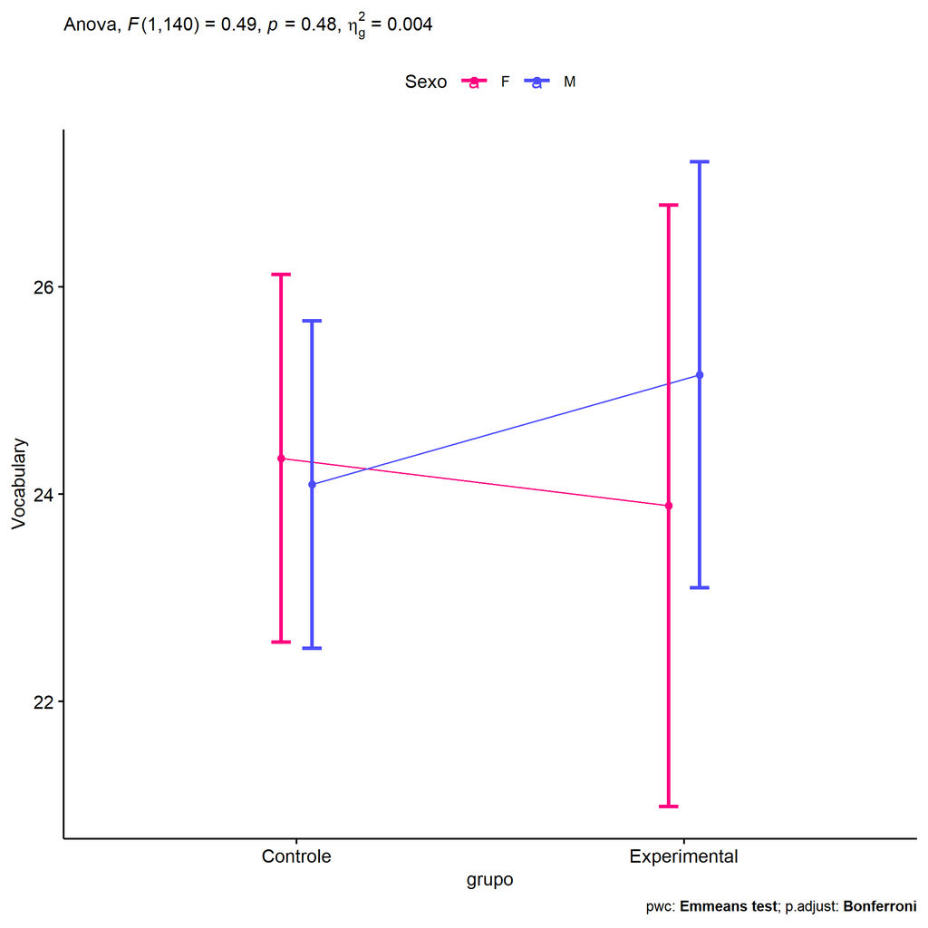

```r
if (length(unique(pdat[["Sexo"]])) >= 2) {
  ggPlotAoC2(pwcs, "grupo", "Sexo", aov, ylab = "Vocabulary",
             subtitle = which(aov$Effect == "grupo:Sexo"), addParam = "errorbar") +
    ggplot2::scale_color_manual(values = color[["Sexo"]]) +
    if (ymin.ci < ymax.ci) ggplot2::ylim(ymin.ci, ymax.ci)
}
```

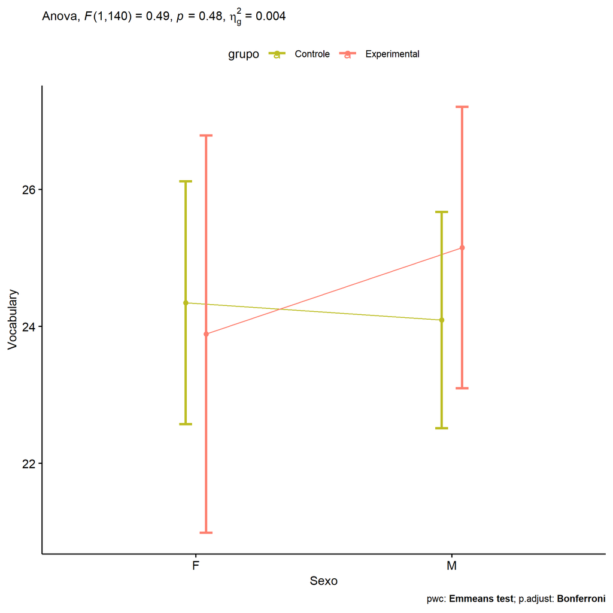

```r
if (length(unique(pdat[["Sexo"]])) >= 2) {
  ggPlotAoC2(pwcs, "Sexo", "grupo", aov, ylab = "Vocabulary",
               subtitle = which(aov$Effect == "grupo:Sexo"), addParam = "errorbar") +
      ggplot2::scale_color_manual(values = color[["grupo"]]) +
      if (ymin.ci < ymax.ci) ggplot2::ylim(ymin.ci, ymax.ci)
}
```

```r
if (length(unique(pdat[["Sexo"]])) >= 2) {
  plots <- twoWayAncovaBoxPlots(
    wdat, "vocab.pos", c("grupo","Sexo"), aov, pwcs, covar = "vocab.pre",
    theme = "classic", color = color[["grupo:Sexo"]],
    subtitle = which(aov$Effect == "grupo:Sexo"))
}
```

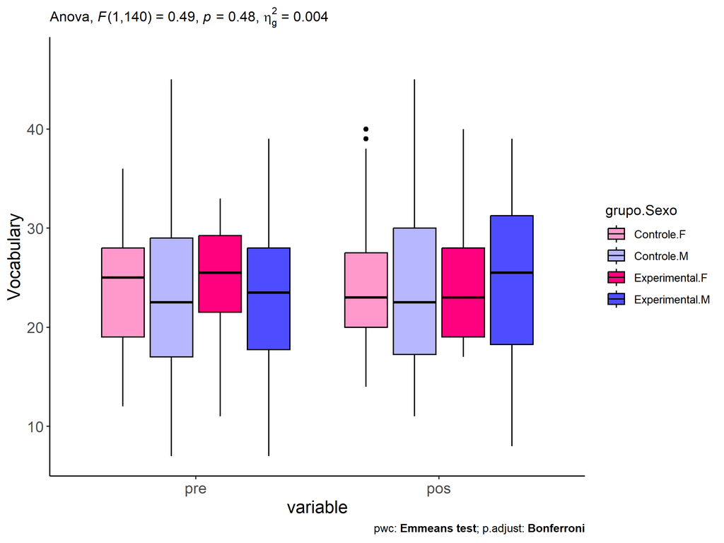

```r
if (length(unique(pdat[["Sexo"]])) >= 2) {
  plots[["grupo:Sexo"]] + ggplot2::ylab("Vocabulary") +
  ggplot2::scale_x_discrete(labels=c('pre', 'pos')) +
  if (ymin < ymax) ggplot2::ylim(ymin, ymax)
}
```

```r
if (length(unique(pdat[["Sexo"]])) >= 2) {
  plots <- twoWayAncovaBoxPlots(
    wdat.long, "vocab", c("grupo","Sexo"), aov, pwc.long,
    pre.post = "time",
    theme = "classic", color = color$prepost)
}
```

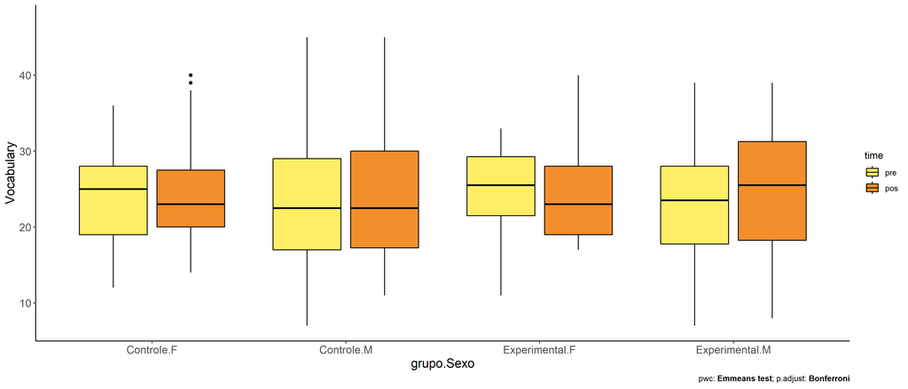

```r
if (length(unique(pdat[["Sexo"]])) >= 2)
  plots[["grupo:Sexo"]] + ggplot2::ylab("Vocabulary") +
    if (ymin < ymax) ggplot2::ylim(ymin, ymax)
```

### Checking linearity assumption

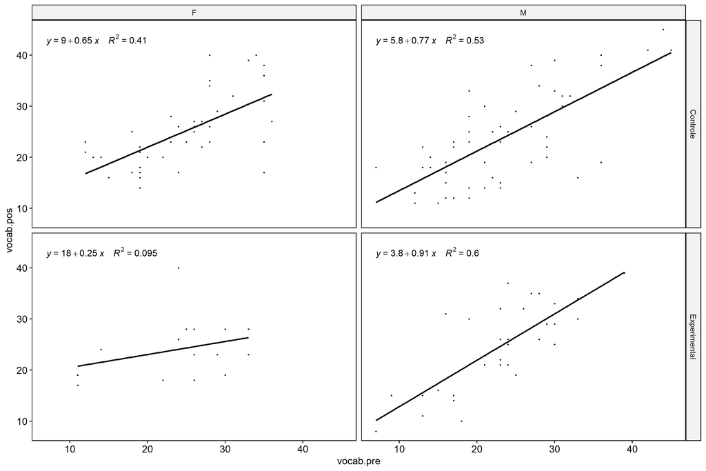

```r
if (length(unique(pdat[["Sexo"]])) >= 2) {
  ggscatter(wdat, x = "vocab.pre", y = "vocab.pos", size = 0.5,
            facet.by = c("grupo","Sexo"), add = "reg.line")+
    stat_regline_equation(
      aes(label =  paste(..eq.label.., ..rr.label.., sep = "~~~~"))
    ) +
    if (ymin < ymax) ggplot2::ylim(ymin, ymax)
}
```

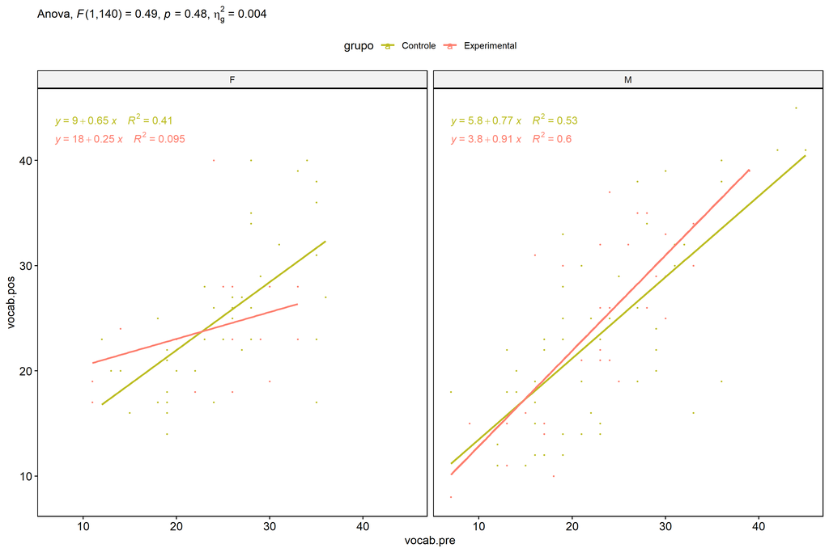

```r
if (length(unique(pdat[["Sexo"]])) >= 2) {
  ggscatter(wdat, x = "vocab.pre", y = "vocab.pos", size = 0.5,
            color = "grupo", facet.by = "Sexo", add = "reg.line")+
    stat_regline_equation(
      aes(label =  paste(..eq.label.., ..rr.label.., sep = "~~~~"), color = grupo)
    ) +
    ggplot2::labs(subtitle = rstatix::get_test_label(aov, detailed = T, row = which(aov$Effect == "grupo:Sexo"))) +
    ggplot2::scale_color_manual(values = color[["grupo"]]) +
    if (ymin < ymax) ggplot2::ylim(ymin, ymax)
}
```

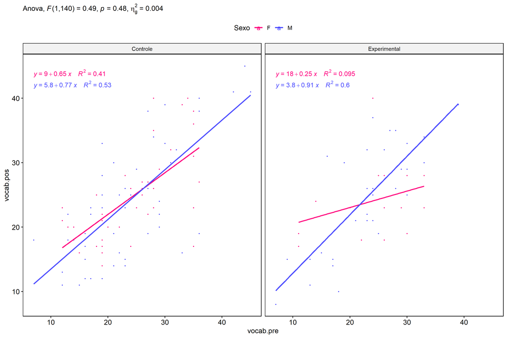

```r
if (length(unique(pdat[["Sexo"]])) >= 2) {
  ggscatter(wdat, x = "vocab.pre", y = "vocab.pos", size = 0.5,
            color = "Sexo", facet.by = "grupo", add = "reg.line")+
    stat_regline_equation(
      aes(label =  paste(..eq.label.., ..rr.label.., sep = "~~~~"), color = Sexo)
    ) +
    ggplot2::labs(subtitle = rstatix::get_test_label(aov, detailed = T, row = which(aov$Effect == "grupo:Sexo"))) +
    ggplot2::scale_color_manual(values = color[["Sexo"]]) +
    if (ymin < ymax) ggplot2::ylim(ymin, ymax)
}
```

### Checking normality and homogeneity

```r
if (length(unique(pdat[["Sexo"]])) >= 2)
  res <- augment(lm(vocab.pos ~ vocab.pre + grupo*Sexo, data = wdat))
```

```r
if (length(unique(pdat[["Sexo"]])) >= 2)
  shapiro_test(res$.resid)
```

```
## # A tibble: 1 × 3
##   variable   statistic p.value
##   <chr>          <dbl>   <dbl>
## 1 res$.resid     0.995   0.917
```

```r
if (length(unique(pdat[["Sexo"]])) >= 2)
  levene_test(res, .resid ~ grupo*Sexo)
```

```
## # A tibble: 1 × 4
##     df1   df2 statistic     p
##   <int> <int>     <dbl> <dbl>
## 1     3   141     0.636 0.593
```

# ANCOVA and Pairwise for two factors **grupo:Zona**

## Without remove non-normal data

```r
pdat = remove_group_data(dat[!is.na(dat[["grupo"]]) & !is.na(dat[["Zona"]]),],
                         "vocab.pos", c("grupo","Zona"))
pdat = pdat[pdat[["Zona"]] %in% do.call(
  intersect, lapply(unique(pdat[["grupo"]]), FUN = function(x) {
    unique(pdat[["Zona"]][which(pdat[["grupo"]] == x)])
  })),]
pdat[["grupo"]] = factor(pdat[["grupo"]], level[["grupo"]])
pdat[["Zona"]] = factor(
  pdat[["Zona"]],
  level[["Zona"]][level[["Zona"]] %in% unique(pdat[["Zona"]])])

pdat.long <- rbind(pdat[,c("id","grupo","Zona")], pdat[,c("id","grupo","Zona")])
pdat.long[["time"]] <- c(rep("pre", nrow(pdat)), rep("pos", nrow(pdat)))
pdat.long[["time"]] <- factor(pdat.long[["time"]], c("pre","pos"))
pdat.long[["vocab"]] <- c(pdat[["vocab.pre"]], pdat[["vocab.pos"]])

if (length(unique(pdat[["Zona"]])) >= 2) {
  aov = anova_test(pdat, vocab.pos ~ vocab.pre + grupo*Zona)
  laov[["grupo:Zona"]] <- get_anova_table(aov)
}
```

```r
if (length(unique(pdat[["Zona"]])) >= 2) {
  pwcs <- list()
  pwcs[["Zona"]] <- emmeans_test(
    group_by(pdat, grupo), vocab.pos ~ Zona,
    covariate = vocab.pre, p.adjust.method = "bonferroni")
  pwcs[["grupo"]] <- emmeans_test(
    group_by(pdat, Zona), vocab.pos ~ grupo,
    covariate = vocab.pre, p.adjust.method = "bonferroni")

  pwc <- plyr::rbind.fill(pwcs[["grupo"]], pwcs[["Zona"]])
  pwc <- pwc[,c("grupo","Zona", colnames(pwc)[!colnames(pwc) %in% c("grupo","Zona")])]
}
```

```r
if (length(unique(pdat[["Zona"]])) >= 2) {
  pwc.long <- emmeans_test(dplyr::group_by_at(pdat.long, c("grupo","Zona")),
                           vocab ~ time,
                           p.adjust.method = "bonferroni")
  lpwc[["grupo:Zona"]] <- plyr::rbind.fill(pwc, pwc.long)
}
```

```r
if (length(unique(pdat[["Zona"]])) >= 2) {
  ds <- get.descriptives(pdat, "vocab.pos", c("grupo","Zona"), covar = "vocab.pre")
  ds <- merge(ds[ds$variable != "vocab.pre",],
              ds[ds$variable == "vocab.pre", !colnames(ds) %in% c("variable")],
              by = c("grupo","Zona"), all.x = T, suffixes = c("", ".vocab.pre"))
  ds <- merge(get_emmeans(pwcs[["grupo"]]), ds,
              by = c("grupo","Zona"), suffixes = c(".emms", ""))
  ds <- ds[,c("grupo","Zona","n","mean.vocab.pre","se.vocab.pre","mean","se",
              "emmean","se.emms","conf.low","conf.high")]

  colnames(ds) <- c("grupo","Zona", "N", paste0(c("M","SE")," (pre)"),
                    paste0(c("M","SE"), " (unadj)"),
                    paste0(c("M", "SE"), " (adj)"), "conf.low", "conf.high")

  lemms[["grupo:Zona"]] <- ds
}
```

## Computing ANCOVA and PairWise After removing non-normal data (OK)

```r
if (length(unique(pdat[["Zona"]])) >= 2) {
  wdat = pdat

  res = residuals(lm(vocab.pos ~ vocab.pre + grupo*Zona, data = wdat))
  non.normal = getNonNormal(res, wdat$id, plimit = 0.05)

  wdat = wdat[!wdat$id %in% non.normal,]

  wdat.long <- rbind(wdat[,c("id","grupo","Zona")], wdat[,c("id","grupo","Zona")])
  wdat.long[["time"]] <- c(rep("pre", nrow(wdat)), rep("pos", nrow(wdat)))
  wdat.long[["time"]] <- factor(wdat.long[["time"]], c("pre","pos"))
  wdat.long[["vocab"]] <- c(wdat[["vocab.pre"]], wdat[["vocab.pos"]])


  ldat[["grupo:Zona"]] = wdat

  (non.normal)
}
```

```
## [1] "P3569"
```

```r
if (length(unique(pdat[["Zona"]])) >= 2) {
  aov = anova_test(wdat, vocab.pos ~ vocab.pre + grupo*Zona)
  laov[["grupo:Zona"]] <- merge(get_anova_table(aov), laov[["grupo:Zona"]],
                                         by="Effect", suffixes = c("","'"))
  df = get_anova_table(aov)
}
```

| Effect | DFn | DFd | F | p | p<.05 | ges |
| --- | --- | --- | --- | --- | --- | --- |
| vocab.pre | 1 | 100 | 140.558 | 0.000 | * | 0.584 |
| grupo | 1 | 100 | 0.034 | 0.854 |  | 0.000 |
| Zona | 1 | 100 | 2.086 | 0.152 |  | 0.020 |
| grupo:Zona | 1 | 100 | 0.538 | 0.465 |  | 0.005 |

```r
if (length(unique(pdat[["Zona"]])) >= 2) {
  pwcs <- list()
  pwcs[["Zona"]] <- emmeans_test(
    group_by(wdat, grupo), vocab.pos ~ Zona,
    covariate = vocab.pre, p.adjust.method = "bonferroni")
  pwcs[["grupo"]] <- emmeans_test(
    group_by(wdat, Zona), vocab.pos ~ grupo,
    covariate = vocab.pre, p.adjust.method = "bonferroni")

  pwc <- plyr::rbind.fill(pwcs[["grupo"]], pwcs[["Zona"]])
  pwc <- pwc[,c("grupo","Zona", colnames(pwc)[!colnames(pwc) %in% c("grupo","Zona")])]
}
```

| grupo | Zona | term | .y. | group1 | group2 | df | statistic | p | p.adj | p.adj.signif |
| --- | --- | --- | --- | --- | --- | --- | --- | --- | --- | --- |
|  | Rural | vocab.pre*grupo | vocab.pos | Controle | Experimental | 100 | -0.448 | 0.655 | 0.655 | ns |
|  | Urbana | vocab.pre*grupo | vocab.pos | Controle | Experimental | 100 | 0.612 | 0.542 | 0.542 | ns |
| Controle |  | vocab.pre*Zona | vocab.pos | Rural | Urbana | 100 | 0.770 | 0.443 | 0.443 | ns |
| Experimental |  | vocab.pre*Zona | vocab.pos | Rural | Urbana | 100 | 1.421 | 0.158 | 0.158 | ns |

```r
if (length(unique(pdat[["Zona"]])) >= 2) {
  pwc.long <- emmeans_test(dplyr::group_by_at(wdat.long, c("grupo","Zona")),
                           vocab ~ time,
                           p.adjust.method = "bonferroni")
  lpwc[["grupo:Zona"]] <- merge(plyr::rbind.fill(pwc, pwc.long),
                                         lpwc[["grupo:Zona"]],
                                         by=c("grupo","Zona","term",".y.","group1","group2"),
                                         suffixes = c("","'"))
}
```

| grupo | Zona | term | .y. | group1 | group2 | df | statistic | p | p.adj | p.adj.signif |
| --- | --- | --- | --- | --- | --- | --- | --- | --- | --- | --- |
| Controle | Rural | time | vocab | pre | pos | 202 | -0.488 | 0.626 | 0.626 | ns |
| Controle | Urbana | time | vocab | pre | pos | 202 | 0.109 | 0.913 | 0.913 | ns |
| Experimental | Rural | time | vocab | pre | pos | 202 | -0.761 | 0.448 | 0.448 | ns |
| Experimental | Urbana | time | vocab | pre | pos | 202 | 0.567 | 0.571 | 0.571 | ns |

```r
if (length(unique(pdat[["Zona"]])) >= 2) {
  ds <- get.descriptives(wdat, "vocab.pos", c("grupo","Zona"), covar = "vocab.pre")
  ds <- merge(ds[ds$variable != "vocab.pre",],
              ds[ds$variable == "vocab.pre", !colnames(ds) %in% c("variable")],
              by = c("grupo","Zona"), all.x = T, suffixes = c("", ".vocab.pre"))
  ds <- merge(get_emmeans(pwcs[["grupo"]]), ds,
              by = c("grupo","Zona"), suffixes = c(".emms", ""))
  ds <- ds[,c("grupo","Zona","n","mean.vocab.pre","se.vocab.pre",
              "mean","se","emmean","se.emms","conf.low","conf.high")]

  colnames(ds) <- c("grupo","Zona", "N", paste0(c("M","SE")," (pre)"),
                    paste0(c("M","SE"), " (unadj)"),
                    paste0(c("M", "SE"), " (adj)"), "conf.low", "conf.high")

  lemms[["grupo:Zona"]] <- merge(ds, lemms[["grupo:Zona"]],
                                          by=c("grupo","Zona"), suffixes = c("","'"))
}
```

| grupo | Zona | N | M (pre) | SE (pre) | M (unadj) | SE (unadj) | M (adj) | SE (adj) | conf.low | conf.high |
| --- | --- | --- | --- | --- | --- | --- | --- | --- | --- | --- |
| Controle | Rural | 55 | 23.691 | 0.958 | 24.418 | 1.103 | 24.129 | 0.702 | 22.735 | 25.522 |
| Controle | Urbana | 11 | 22.455 | 3.178 | 22.091 | 2.462 | 22.803 | 1.571 | 19.687 | 25.919 |
| Experimental | Rural | 34 | 22.618 | 1.247 | 24.059 | 1.346 | 24.639 | 0.894 | 22.865 | 26.412 |
| Experimental | Urbana | 5 | 26.200 | 3.338 | 23.400 | 3.187 | 21.078 | 2.336 | 16.443 | 25.712 |

### Plots for ancova

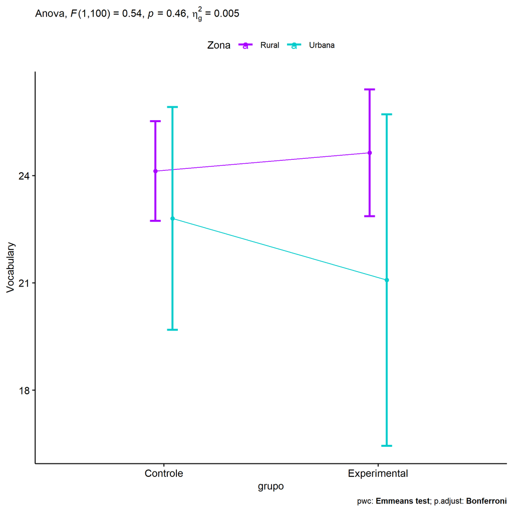

```r
if (length(unique(pdat[["Zona"]])) >= 2) {
  ggPlotAoC2(pwcs, "grupo", "Zona", aov, ylab = "Vocabulary",
             subtitle = which(aov$Effect == "grupo:Zona"), addParam = "errorbar") +
    ggplot2::scale_color_manual(values = color[["Zona"]]) +
    if (ymin.ci < ymax.ci) ggplot2::ylim(ymin.ci, ymax.ci)
}
```

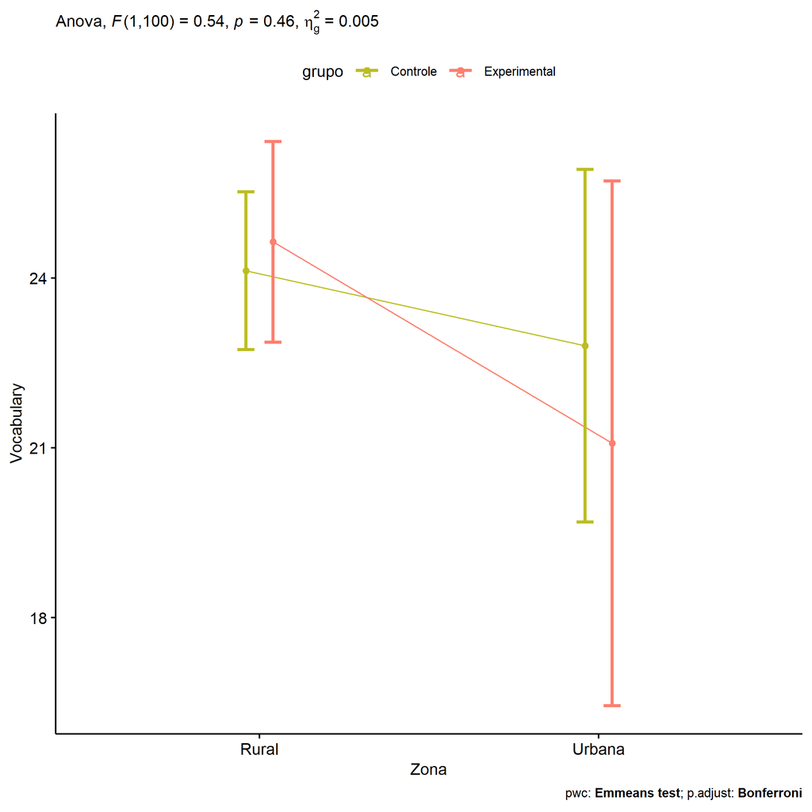

```r
if (length(unique(pdat[["Zona"]])) >= 2) {
  ggPlotAoC2(pwcs, "Zona", "grupo", aov, ylab = "Vocabulary",
               subtitle = which(aov$Effect == "grupo:Zona"), addParam = "errorbar") +
      ggplot2::scale_color_manual(values = color[["grupo"]]) +
      if (ymin.ci < ymax.ci) ggplot2::ylim(ymin.ci, ymax.ci)
}
```

```r
if (length(unique(pdat[["Zona"]])) >= 2) {
  plots <- twoWayAncovaBoxPlots(
    wdat, "vocab.pos", c("grupo","Zona"), aov, pwcs, covar = "vocab.pre",
    theme = "classic", color = color[["grupo:Zona"]],
    subtitle = which(aov$Effect == "grupo:Zona"))
}
```

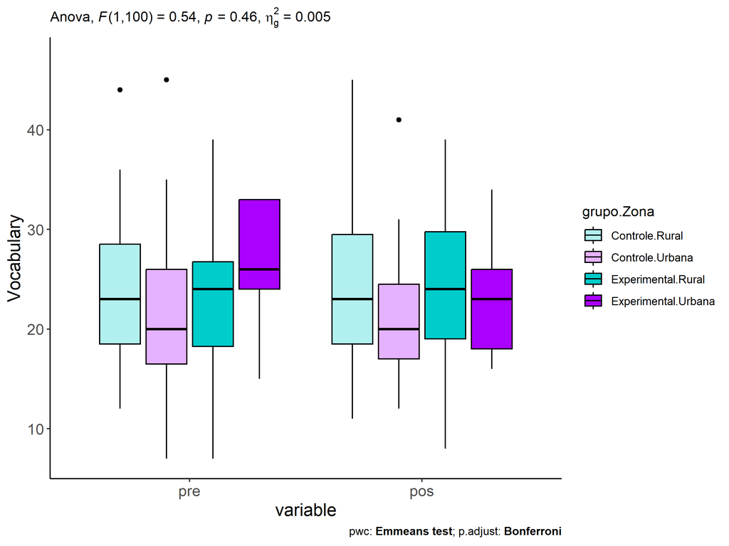

```r
if (length(unique(pdat[["Zona"]])) >= 2) {
  plots[["grupo:Zona"]] + ggplot2::ylab("Vocabulary") +
  ggplot2::scale_x_discrete(labels=c('pre', 'pos')) +
  if (ymin < ymax) ggplot2::ylim(ymin, ymax)
}
```

```r
if (length(unique(pdat[["Zona"]])) >= 2) {
  plots <- twoWayAncovaBoxPlots(
    wdat.long, "vocab", c("grupo","Zona"), aov, pwc.long,
    pre.post = "time",
    theme = "classic", color = color$prepost)
}
```

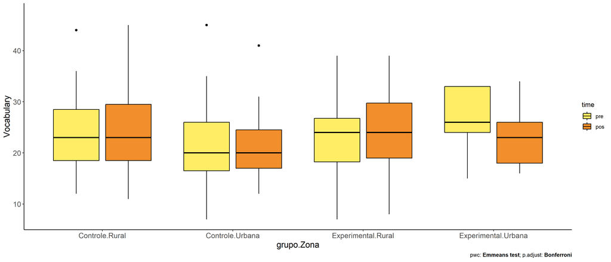

```r
if (length(unique(pdat[["Zona"]])) >= 2)
  plots[["grupo:Zona"]] + ggplot2::ylab("Vocabulary") +
    if (ymin < ymax) ggplot2::ylim(ymin, ymax)
```

### Checking linearity assumption

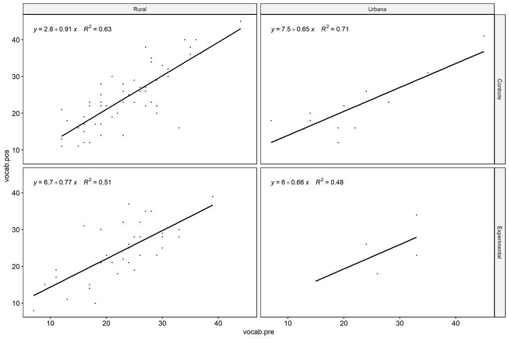

```r
if (length(unique(pdat[["Zona"]])) >= 2) {
  ggscatter(wdat, x = "vocab.pre", y = "vocab.pos", size = 0.5,
            facet.by = c("grupo","Zona"), add = "reg.line")+
    stat_regline_equation(
      aes(label =  paste(..eq.label.., ..rr.label.., sep = "~~~~"))
    ) +
    if (ymin < ymax) ggplot2::ylim(ymin, ymax)
}
```

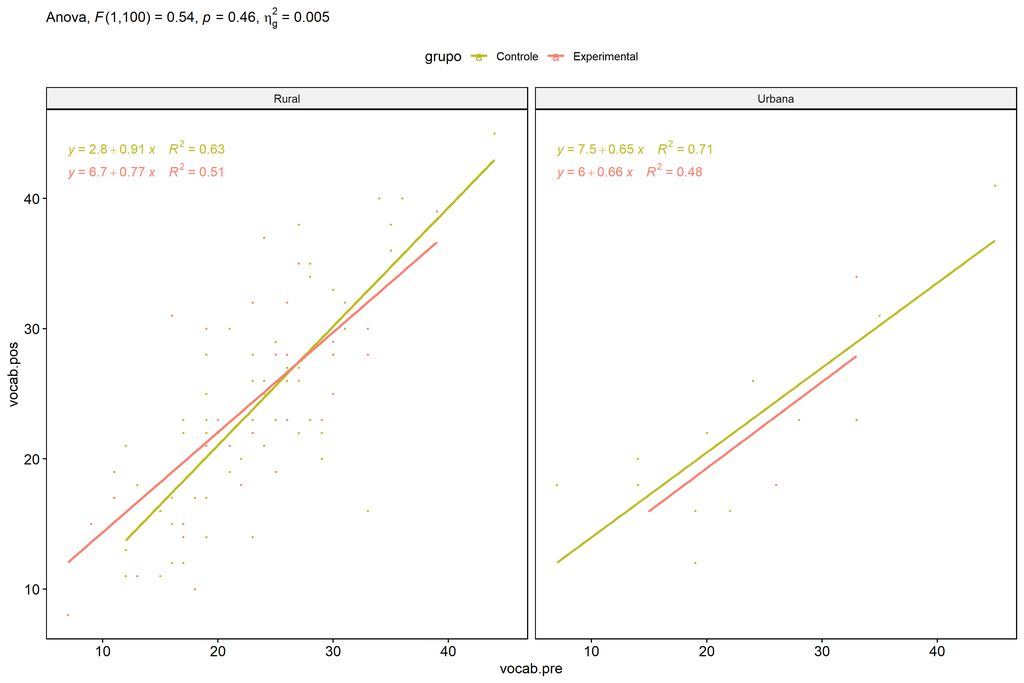

```r
if (length(unique(pdat[["Zona"]])) >= 2) {
  ggscatter(wdat, x = "vocab.pre", y = "vocab.pos", size = 0.5,
            color = "grupo", facet.by = "Zona", add = "reg.line")+
    stat_regline_equation(
      aes(label =  paste(..eq.label.., ..rr.label.., sep = "~~~~"), color = grupo)
    ) +
    ggplot2::labs(subtitle = rstatix::get_test_label(aov, detailed = T, row = which(aov$Effect == "grupo:Zona"))) +
    ggplot2::scale_color_manual(values = color[["grupo"]]) +
    if (ymin < ymax) ggplot2::ylim(ymin, ymax)
}
```

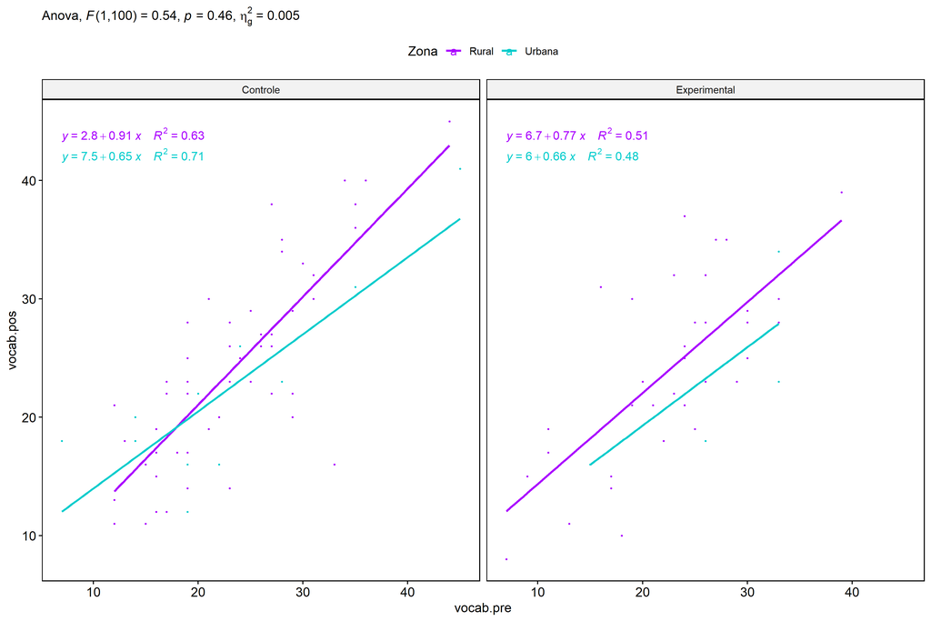

```r
if (length(unique(pdat[["Zona"]])) >= 2) {
  ggscatter(wdat, x = "vocab.pre", y = "vocab.pos", size = 0.5,
            color = "Zona", facet.by = "grupo", add = "reg.line")+
    stat_regline_equation(
      aes(label =  paste(..eq.label.., ..rr.label.., sep = "~~~~"), color = Zona)
    ) +
    ggplot2::labs(subtitle = rstatix::get_test_label(aov, detailed = T, row = which(aov$Effect == "grupo:Zona"))) +
    ggplot2::scale_color_manual(values = color[["Zona"]]) +
    if (ymin < ymax) ggplot2::ylim(ymin, ymax)
}
```

### Checking normality and homogeneity

```r
if (length(unique(pdat[["Zona"]])) >= 2)
  res <- augment(lm(vocab.pos ~ vocab.pre + grupo*Zona, data = wdat))
```

```r
if (length(unique(pdat[["Zona"]])) >= 2)
  shapiro_test(res$.resid)
```

```
## # A tibble: 1 × 3
##   variable   statistic p.value
##   <chr>          <dbl>   <dbl>
## 1 res$.resid     0.992   0.826
```

```r
if (length(unique(pdat[["Zona"]])) >= 2)
  levene_test(res, .resid ~ grupo*Zona)
```

```
## # A tibble: 1 × 4
##     df1   df2 statistic     p
##   <int> <int>     <dbl> <dbl>
## 1     3   101     0.234 0.873
```